# Price disaggregation protocol.

Sbrana, Sabatella

2025-12-04

## Introduction

The protocol is part of the SURIMI project and is designed to extract the prices of individual species over time for each landing port.

1. The [FDI landing dataset](https://jeodpp.jrc.ec.europa.eu/ftp/jrc-opendata/FAD/fdi/FDI_spatial_data_EU28.zip), which provides detailed records of landings over time by year, country, GSA, gear, vessel length and ices-cell.
2. The FAO Geographical Sub-Areas: Area of application, comprised of the Mediterranean and the Black Sea, as Major Fishing Area 37.
3. The [FAO ASFIS List of Species for Fisheries](https://www.fao.org/fishery/static/ASFIS/ASFIS_sp.zip) which represents the standard taxonomic reference system for the FAO Statistics Team.

This information is crucial for providing context to the landing data and for connecting fishing effort with species availability and price patterns at the port level.

## Disaggregation procedure

Save the data input to a folder and set the folder as the data location in the R environment:

```r
wd = "SET YOUR DATA FOLDER DIRECTORY"
```

### Data manipulation for a case study area

Users could establish parameters for their case study, which will subsequently inform the procedure. This study examined the activity of bottom otter trawlers (OTB) and purse seiners (PS) within the Spanish waters of GSA 6.

```r
CS_name = "FAO GSA06 "
Gear = c("OTB", "PS")
Year = c(2013:2022)
Country = c("ESP")
GSAa_CS = c("GSA6")
GSAs_CS = c("GSA06")
```

```r
library(dplyr)
library(ggplot2)
library(ggrepel)
library(ggpmisc)
library(openxlsx)
library(paletteer)
library(patchwork)
library(reshape2)
library(rnaturalearth)
library(rnaturalearthdata)
library(sf)
library(tidyverse)
library(tidytext)
library(webr)
library(webshot2)
```

### Step 1 - Open and subset FDI Landing data

The FDI data were opened and filtered by gear type, year, and country. The GSA polygon was then used to extract spatial landings for Bottom Otter Trawlers (OTB) and Purse Seiners (PS). Figures present selected results showing the total landing values by gear type.

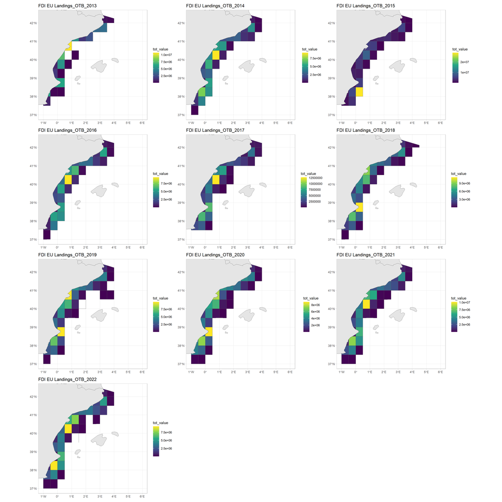

Total landings coverage for the case study area - resulting from FDI data

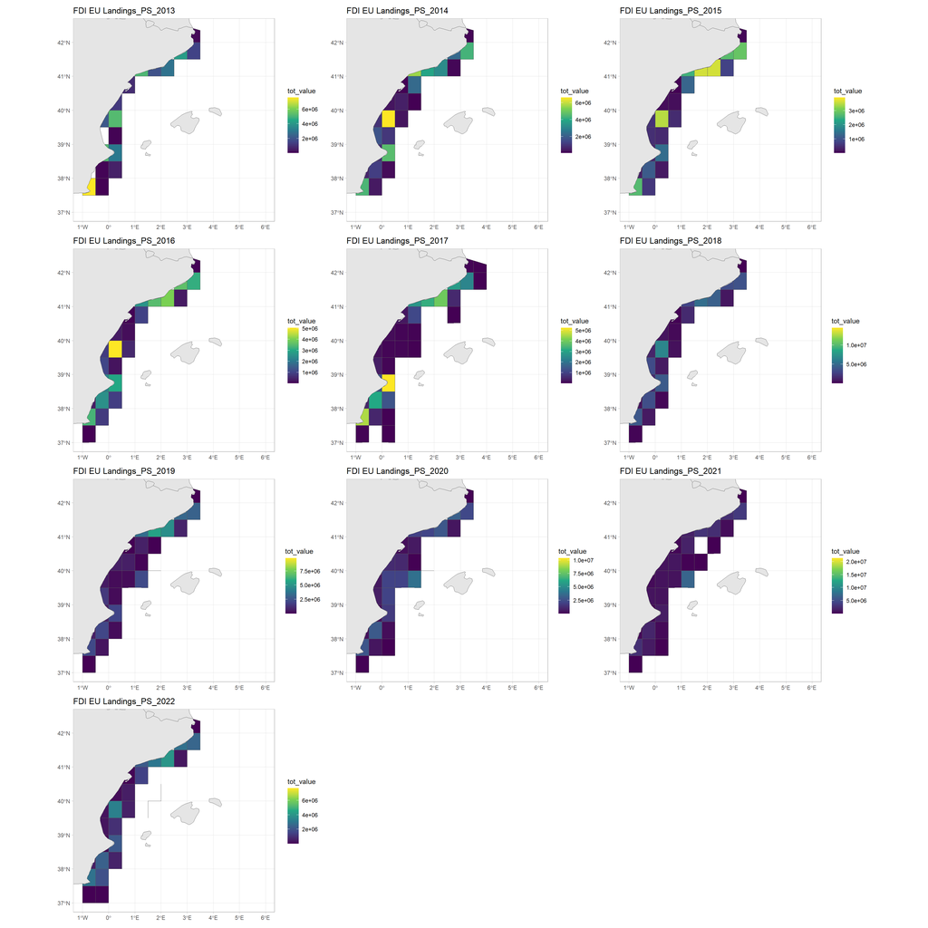

Total landings coverage for the case study area - resulting from FDI data

```r
#Set parameter for the map
world <- ne_countries(scale = "medium", returnclass = "sf", continent = "europe")
world = st_transform(world, crs = st_crs(GSA))

xmin = as.numeric(st_bbox(GSA)[1])-0.0001
xmax = as.numeric(st_bbox(GSA)[3])+0.0001
ymin = as.numeric(st_bbox(GSA)[2])-0.0001
ymax = as.numeric(st_bbox(GSA)[4])+0.0001


#landing

for(g in 1 : length(Gear)){

l_data = purrr::map(landing_sf, ~ .x %>%
           filter(gear_type == Gear[g]))

plot_list <- list()

 for(y in 1: length(Year)){
l_plot = l_data[[y]] %>%
        group_by(year,gear_type,sub_region,cscode) %>%
        summarise(tot_kg = sum(totwghtlandg), tot_value = sum(totvallandg)) %>%
       ggplot()+
         geom_sf(aes(fill = tot_value))+
         geom_sf(data = world)+
         coord_sf(xlim = c(xmin, xmax), ylim = c(ymin, ymax))+
         scale_fill_viridis_c(option = "D")+
         ggtitle(paste0("FDI EU Landings_",Gear[g],"_",Year[y]))+
         theme_light()

plot_list[[y]] <- l_plot
 }
 combined_plot <- wrap_plots(plotlist = plot_list, ncol = 3)
 print(combined_plot)

  cat("-----")
 }
```

Save all the filtered data in a specific folder fd = “CaseStudy/”

```r
fd = "CaseStudy/"

saveRDS(landing_sf, paste0(fd,"Landing_sf.RData"))

saveRDS(
  purrr::map(landing_sf, ~ .x %>%
               st_drop_geometry() %>%
              rename(id = cscode, gear = gear_type, vlength = vessel_length, tot_fish_weight = totwghtlandg,    tot_fish_value = totvallandg)),
  paste0(fd,"landing_CS.rData"))
```

### Step 2 - Filter and clean landing data

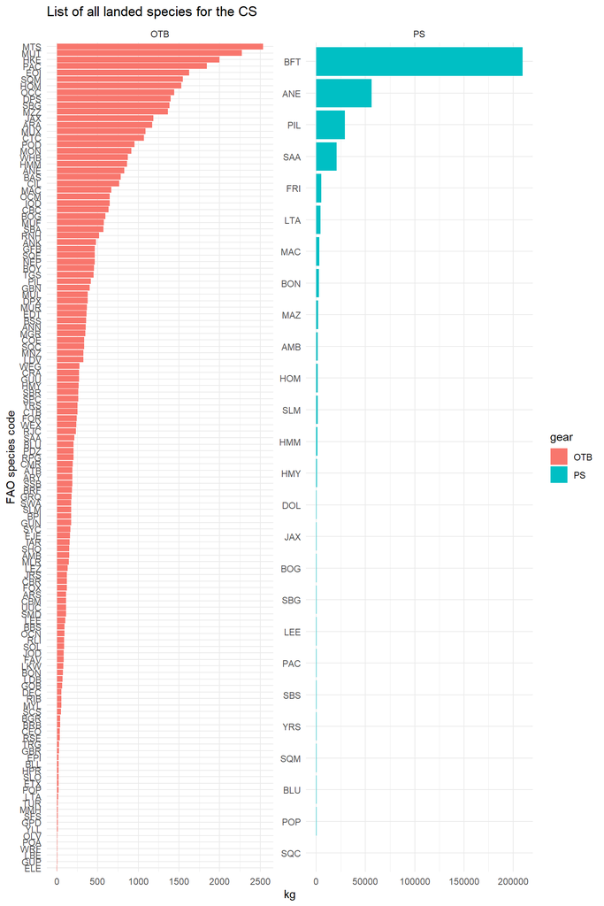

FDI landing species by Gear (OTB and PS) for the case study area (GSA6)

```r
landing_CS = readRDS(paste0(fd,"Landing_CS.RData"))

euro_species = purrr::map(
               landing_CS, ~ .x %>%
               filter(tot_fish_weight != 0)
               )

euro_species_df = do.call("rbind", euro_species)

species_all_years <- euro_species_df %>%
  group_by(gear,species) %>%
  distinct(year, species) %>%
  summarise(n_years = n_distinct(year), .groups = "drop") %>%
  filter(n_years == length(unique(euro_species_df$year)))

euro_species_filtered <- euro_species_df %>%
                         inner_join(species_all_years, by = c("species", "gear"))

# remove quarter

euro_species_filtered <- euro_species_filtered %>%
                           group_by(year, gear, species) %>%
                           summarise(yearly_kg = mean(tot_fish_weight)*1000, yearly_value = mean(tot_fish_value))

euro_species_filtered %>%
   group_by(species, gear) %>%
   summarise(mvalue = mean(yearly_value), kg = (mean(yearly_kg))) %>%
  ggplot() +
  geom_bar(aes(x = kg, y = reorder_within(species, kg, gear), fill = gear), stat = "identity")+
  ylab("FAO species code")+
  facet_wrap(~ gear, scales = "free")+
  xlab("kg")+
  ggtitle("List of all landed species for the CS")+
  scale_y_reordered()+
  theme_minimal()
```

```r
ggsave(filename = "Result/land_spe.jpeg", height = 12)

 species_sel <- euro_species_filtered %>%
  group_by(species, gear) %>%
  summarise(m_kg = mean(yearly_kg), .groups = "drop") %>%
  group_by(gear) %>%
  slice_max(m_kg, n = 15) %>%
  ungroup()
```

### Step 3 - Add species price

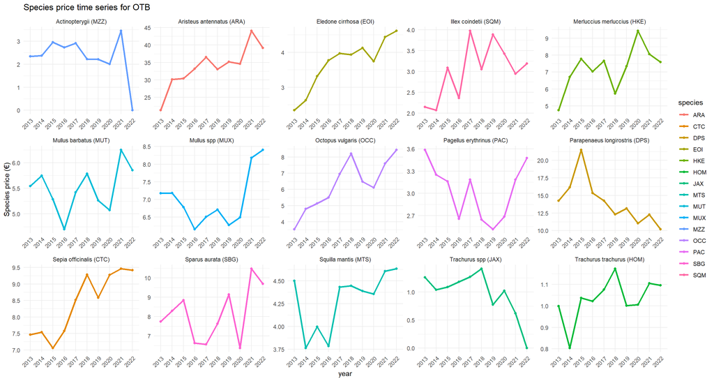

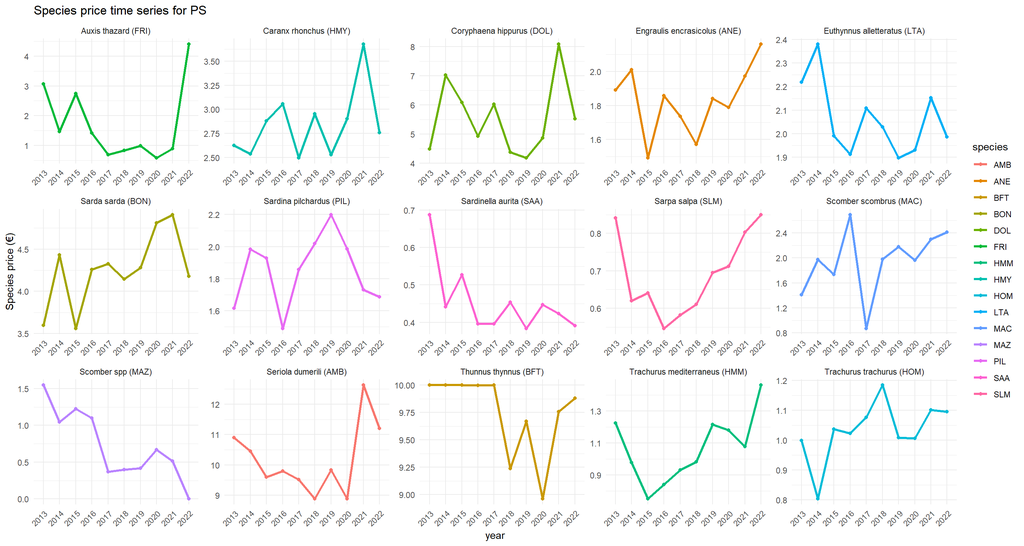

```r
FDI_land_spe_filter <- euro_species_filtered %>%
                    inner_join(species_sel, by = c("species", "gear")) %>%
                    select(-m_kg) %>%
                    mutate(price = yearly_value/yearly_kg)

FAO_sp = read.csv("Data Input/ASFIS_sp_2025.csv") %>% select("Alpha3_Code","Scientific_Name") %>% rename("species" = "Alpha3_Code")

FDI_land_spe_filter$year = as.character(FDI_land_spe_filter$year)

gear_filter = unique(FDI_land_spe_filter$gear)

for (g in seq_along(gear_filter)) {

  print(FDI_land_spe_filter %>%
    filter(gear == gear_filter[g]) %>%
  group_by(year, species) %>%
  summarise(m_price = mean(price)) %>%
  left_join(FAO_sp) %>%
  mutate(sp_id = paste0(Scientific_Name," (",species,")")) %>%

        ggplot(aes(x = year, y = m_price, color = species,
                   group = species)) +
        geom_line(size = 1.1) +
        geom_point() +
        facet_wrap(~ sp_id, scales = "free", ncol = 5) +
        theme_minimal() +
        ggtitle(paste0("Species price time series for ", gear_filter[g])) +
        ylab("Species price (€)")+
        theme(axis.text.x = element_text(angle = 45, vjust = 1, hjust = 1))
)
}
```

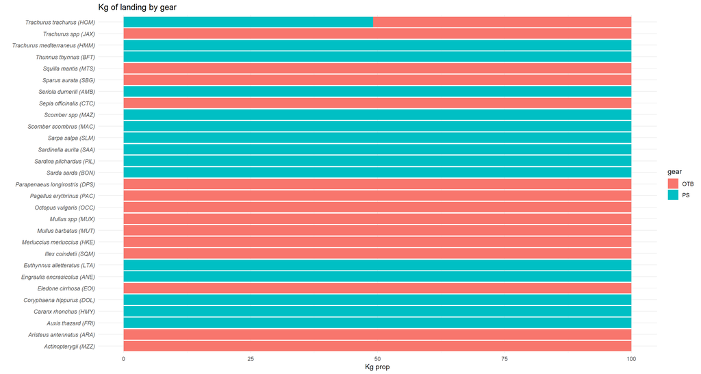

```r
FDI_land_spe_filter %>%
   group_by(gear,species) %>%
   summarise(kg_gear = sum(yearly_kg)) %>%
  group_by(species) %>%
  mutate(kg_tot = sum(kg_gear)) %>%
  mutate(kg_prop = (kg_gear/kg_tot)*100) %>%
  left_join(FAO_sp) %>%
  mutate(sp_id = paste0(Scientific_Name," (",species,")")) %>%
  ggplot() +
  geom_bar(aes(y = sp_id, x = kg_prop, fill = gear),stat = "identity") +
  labs(title = "Kg of landing by gear", y = "", x = "Kg prop") +
  theme_minimal()+
  theme(axis.text.y = element_text(face = "italic"))
```

Save data filtered

```r
saveRDS(FDI_land_spe_filter, paste0(fd,"FDI_land_spe_filter.RData"))

write.csv(FDI_land_spe_filter, "Result/Species_Prices.csv", row.names = F)
```